# Analysis of the Lighthouse Data

Florian Stijven

2024-04-12

```r
library(ggplot2)
library(dplyr)
library(tidyr)
library(mmrm)
library(TCT)
library(gtsummary)
library(emmeans)
```

# 1 Introduction

In this report, we analyze the Lighthouse data. These are data from a randomized trial in Alzheimer’s disease where the ADAS-Cog score has been evaluated at pre-determined measurement occasions. Additionally, baseline covariates are available; these will be adjusted for to increase efficiency.

We first read and explore the data. Next, we fit a mixed model for repeated measures (MMRM) and present the corresponding results. Finally, we use this fitted mixed model to estimate the treatment effect on the time scale with the meta time-component test (meta TCT) methodology.

# 2 Data Exploration

The Lighthouse data are read via the SAS data file. These data are in a partially long format because every post-randomization measurement has its own row, but the baseline measurement is represented by a column. For applying meta TCT, we need to fit a mixed model where the baseline measurement is also treated as a response instead of a baseline covariate. Hence, we reformat the data accordingly.

```r
# Read the sas-data set.
data_lighthouse = haven::read_sas("tct_adascog.sas7bdat")
# The original data are not in the long format because there is no separate row
# for the ADASCog at baseline. We recode the data into the long format.
data_lighthouse_long = data_lighthouse %>%
  # Add baseline value to the change score to get the original ADASCog score.
  mutate(CHG = CHG + BASVAL) %>%
  pivot_wider(names_from = "WEEK",
              values_from = "CHG",
              names_prefix = "Week_") %>%
  rename(Week_0 = "BASVAL") %>%
  pivot_longer(cols = starts_with("Week"),
               names_to = "Week",
               values_to = "ADASCog") %>%
  mutate(Week_int = as.integer(stringr::str_sub(Week, start = 6)))
```

The baseline covariates and ADAS-Cog scores are summarized by treatment group in Table 2.1. By randomization, the distribution of baseline covariates should be identical across treatment groups, apart from discrepancies due to sampling variability. This table, however, highlights two potential issues:

1. At the post-randomization measurement occasions, there appears to be a discrepancy in the proportion of missing values between the treatment groups.
2. There are centers with patients in only one of the treatment groups. This does not cause problems in our further analyses. Still, this is not ideal.

```r
data_lighthouse_long %>%
  select(-Week_int) %>%
  pivot_wider(
    names_from = "Week",
    values_from = "ADASCog",
    names_prefix = "ADASCog"
  ) %>%
  select(-SUBJID) %>%
  tbl_summary(by = "TRT", missing_text = "(Missing)") %>%
  modify_caption("Patient Characteristics by Treatment Group")
```

Table 2.1: Patient Characteristics by Treatment Group

| **Characteristic** | **Active**, N = 148<sup>1</sup> | **Placebo**, N = 79<sup>1</sup> |
| --- | --- | --- |
| Pooled Site Group 1 |  |  |
| CA | 6 (4.1%) | 3 (3.8%) |
| CA_OTHER | 3 (2.0%) | 1 (1.3%) |
| ESP | 10 (6.8%) | 6 (7.6%) |
| FL_Alzheimerâ€™s Research and Treatment Center | 6 (4.1%) | 2 (2.5%) |
| FL_Anchor Neuroscience | 0 (0%) | 1 (1.3%) |
| FL_Bioclinica Research | 3 (2.0%) | 2 (2.5%) |
| FL_JEM Research | 6 (4.1%) | 1 (1.3%) |
| FL_MD Clinical | 3 (2.0%) | 0 (0%) |
| FL_Miami Dade Medical Reserch Institute | 11 (7.4%) | 4 (5.1%) |
| FL_Neuropsychiatric Research Center of SW Florida | 0 (0%) | 2 (2.5%) |
| FL_QTrials, Inc | 3 (2.0%) | 1 (1.3%) |
| FRA | 7 (4.7%) | 7 (8.9%) |
| Future Care/Brain Matters Research/Sensible | 3 (2.0%) | 1 (1.3%) |
| GA_Medical Research & Health Education Foundation | 4 (2.7%) | 2 (2.5%) |
| GBR | 10 (6.8%) | 4 (5.1%) |
| KS/ID | 1 (0.7%) | 0 (0%) |
| MA | 6 (4.1%) | 4 (5.1%) |
| MS/IL | 7 (4.7%) | 0 (0%) |
| NC | 2 (1.4%) | 3 (3.8%) |
| NJ | 3 (2.0%) | 3 (3.8%) |
| NLD | 6 (4.1%) | 5 (6.3%) |
| NM/AZ | 4 (2.7%) | 1 (1.3%) |
| NV/NeuroStudies/Stedman/Brain Matters - SS/Indago | 3 (2.0%) | 5 (6.3%) |
| NY_ALBANY | 6 (4.1%) | 1 (1.3%) |
| NY_OTHER | 4 (2.7%) | 1 (1.3%) |
| OH | 3 (2.0%) | 2 (2.5%) |
| OR | 4 (2.7%) | 3 (3.8%) |
| PA | 1 (0.7%) | 0 (0%) |
| POL | 15 (10%) | 10 (13%) |
| TX | 3 (2.0%) | 1 (1.3%) |
| VA/Suncoast Neuroscience | 2 (1.4%) | 2 (2.5%) |
| WA | 3 (2.0%) | 1 (1.3%) |
| MMSE Baseline | 18.8 (16.0, 21.0) | 18.0 (15.8, 20.8) |
| ApoE4 Stratum (N) |  |  |
| 1 | 98 (66%) | 53 (67%) |
| 2 | 50 (34%) | 26 (33%) |
| Acetylcholinesterase Inhibitors/Memantin |  |  |
| N | 45 (30%) | 13 (16%) |
| Y | 103 (70%) | 66 (84%) |
| ADASCogWeek_0 | 22 (17, 28) | 22 (18, 28) |
| ADASCogWeek_12 | 23 (16, 30) | 23 (17, 29) |
| (Missing) | 7 | 1 |
| ADASCogWeek_24 | 24 (16, 31) | 24 (19, 34) |
| (Missing) | 24 | 4 |
| ADASCogWeek_40 | 24 (17, 32) | 29 (21, 35) |
| (Missing) | 39 | 8 |
| ADASCogWeek_48 | 24 (16, 33) | 27 (19, 37) |
| (Missing) | 52 | 10 |

<sup>1</sup> n (%); Median (IQR)

To investigate the discrepancies in the proportions of missing values, we test whether the proportions of missing values are equal at each measurement occasion. The results are shown in Table 2.2 and clearly show that there are more missing values in the active treatment group. The magnitude of missingness is also substantial; 35% of the values are missing at 48 weeks in the active treatment group. In what follows, we assume missing at random (MAR). A MMRM leads to valid inferences under MAR regardless of the proportion of missing values; however, the results could be sensitive to small violations of MAR because there are many missing values.

```r
data_lighthouse_long %>%
  select(-Week_int) %>%
  pivot_wider(names_from = "Week",
              values_from = "ADASCog",
              names_prefix = "ADASCog") %>%
  mutate(
    missing_Week_0 = is.na(ADASCogWeek_0),
    missing_Week_12 = is.na(ADASCogWeek_12),
    missing_Week_24 = is.na(ADASCogWeek_24),
    missing_Week_40 = is.na(ADASCogWeek_40),
    missing_Week_48 = is.na(ADASCogWeek_48)
  ) %>%
  select(
    missing_Week_12,
    missing_Week_24,
    missing_Week_40,
    missing_Week_48,
    TRT
  ) %>%
  tbl_summary(by = "TRT", missing_text = "(Missing)") %>%
  modify_caption("Comparison of Proportion of Missing Values.") %>%
  add_p(test = list(all_categorical() ~ "fisher.test")) %>%
  as_gt()
```

Table 2.2: Comparison of Proportion of Missing Values.

| **Characteristic** | **Active**, N = 148<sup>1</sup> | **Placebo**, N = 79<sup>1</sup> | **p-value**<sup>2</sup> |
| --- | --- | --- | --- |
| missing_Week_12 | 7 (4.7%) | 1 (1.3%) | 0.3 |
| missing_Week_24 | 24 (16%) | 4 (5.1%) | 0.018 |
| missing_Week_40 | 39 (26%) | 8 (10%) | 0.004 |
| missing_Week_48 | 52 (35%) | 10 (13%) | <0.001 |

<sup>1</sup> n (%)  
<sup>2</sup> Fisher’s exact test

In Figure 2.1, the patient-specific longitudinal profiles are plotted alongside the treatment specific mean profiles. Note that the mean profiles are based on a complete case analysis. This figure reveals (i) that there is a lot of between-patient variability and (ii) that there is a treatment effect that increases with time.

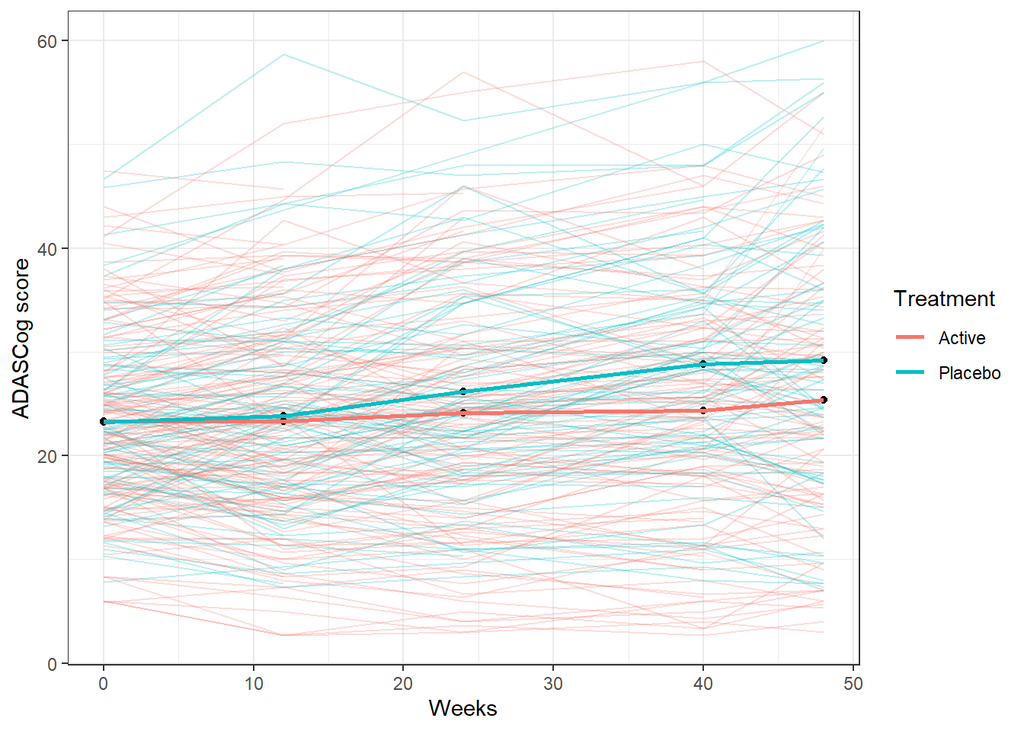

Figure 2.1: Plot of patient-specific profiles together with the treatment specific mean profiles based on a complete case analysis.

```r
data_lighthouse_long %>%
  na.omit() %>%
  ggplot(aes(x = Week_int, y = ADASCog, color = TRT)) +
  geom_line(aes(group = SUBJID), alpha = 0.25) +
  geom_point(
    data = data_lighthouse_long %>%
      group_by(TRT, Week, Week_int) %>%
      summarize(mean_score = mean(ADASCog, na.rm = TRUE)) %>%
      ungroup(),
    mapping = aes(x = Week_int, y = mean_score),
    color = "black"
  ) +
  geom_line(
    data = data_lighthouse_long %>%
      group_by(TRT, Week, Week_int) %>%
      summarize(mean_score = mean(ADASCog, na.rm = TRUE)) %>%
      ungroup(),
    mapping = aes(x = Week_int, y = mean_score, group = TRT),
    linewidth = 1
  ) +
  xlab("Weeks") +
  ylab("ADASCog score") +
  scale_color_discrete(name = "Treatment") +
  theme_bw()
```

# 3 Mixed Model for Repeated Measures

We now fit a MMRM where the vector of ADAS-Cog scores at baseline, 12, 24, 40, and 48 weeks is the response variable. The model is fitted with restricted maximum likelihood. We also add the following baseline covariates in the model:

- `SITEGR1`: This is a categorical variable for the study sites; we include a main effect for this variable.
- `AAPOEN`: This is the APOE Allele status. We include an interaction between the measurement occasion and this variable.

In this model, we also assume that the mean ADAS-Cog scores at baseline are equal between both treatment groups. This holds by randomization. The mixed model is fitted with `mmrm()` from the `mmrm` R package.

```r
# Fit model for the full ADASCog vector, including the baseline response. For
# the TCT methods, it is most ideal to assume that the mean response at baseline
# is equal in both treatment groups. This can be "forced" by setting the
# treatment variable to "placebo" for all measurements at baseline.
data_lighthouse_long = data_lighthouse_long %>%
  mutate(
    Week = factor(Week),
    SITEGR1 = factor(SITEGR1),
    AAPOEN = factor(AAPOEN),
    TRT = ifelse(Week_int == 0L, "Placebo", TRT),
    TRT = factor(TRT)
  )
mmrm_fit_tct = mmrm(
  formula = ADASCog ~ Week:TRT + SITEGR1 + AAPOEN*Week +
    us(Week | SUBJID),
  data = data_lighthouse_long,
  method = "Kenward-Roger"
)
# summary(mmrm_fit_tct)
```

We test for a treatment effect using the F-test with the Kenward-Rogers degrees of freedom approximation.

```r
anova_mmrm = car::Anova(mmrm_fit_tct)
anova_mmrm
```

```
## Analysis of Fixed Effect Table (Type II F tests)
##             Num Df Denom Df F Statistic   Pr(>=F)
## SITEGR1         31   194.35      3.3045 2.215e-07 ***
## AAPOEN           1   185.33      0.1949   0.65938
## Week             4   192.07     24.2775 2.854e-16 ***
## Week:TRT         4   186.09      3.1562   0.01539 *
## AAPOEN:Week      4   192.39      2.7595   0.02905 *
## ---
## Signif. codes:  0 '***' 0.001 '**' 0.01 '*' 0.05 '.' 0.1 ' ' 1
```

```r
row_number_trt = which(rownames(anova_mmrm) ==  "Week:TRT")
p_trt_effect = anova_mmrm[["Pr(>=F)"]][row_number_trt]
```

The p-value for the F-test is 0.015. There is thus is a significant treatment effect, but it is unclear how relevant this effect really is. A first step towards interpreting the magnitude of the treatment effect is to look at the estimated mean differences in ADAS-Cog scores.

Because we have included baseline covariates, we have to carefully define the treatment group-specific mean ADAS-Cog scores at the various measurement occasions. In what follows, we consider the estimated marginal means (EMMs, also known as least-squares means) where the factor levels of the center variable and the APOE variable receive weights proportional to their observed frequencies in the data. Alternatively, we could use equal weights for these factors, meaning that each center and APOE level receives the same weight. Which weights are most appropriate depends on whether these factors were controlled by the researchers and on the population one wishes to make inferences on.

The EMMs with proportional weights and the corresponding contrasts by measurement occasion are estimated with `emmeans()` and `contrast()` from the `emmeans` R package; the corresponding output is printed below. These contrasts indicate that the treatment effect increases with time. Still, it remains difficult to appreciate the relevance of the observed treatment effect, i.e., is a 2 or 3 points mean difference on the ADAS-Cog scale meaningful?

```r
# The least squares means are required for meta TCT.
ls_means_prop = emmeans::emmeans(mmrm_fit_tct, ~ TRT | Week, weights = "proportional")
```

```
## NOTE: A nesting structure was detected in the fitted model:
##     TRT %in% Week
```

```r
ls_means_prop
```

```
## Week = Week_0:
##  TRT     emmean    SE  df lower.CL upper.CL
##  Placebo   23.2 0.472 189     22.3     24.2
##
## Week = Week_12:
##  TRT     emmean    SE  df lower.CL upper.CL
##  Active    23.4 0.617 223     22.2     24.6
##  Placebo   24.1 0.709 283     22.7     25.5
##
## Week = Week_24:
##  TRT     emmean    SE  df lower.CL upper.CL
##  Active    24.5 0.711 222     23.1     25.9
##  Placebo   26.0 0.810 278     24.4     27.6
##
## Week = Week_40:
##  TRT     emmean    SE  df lower.CL upper.CL
##  Active    25.4 0.744 229     24.0     26.9
##  Placebo   28.2 0.846 274     26.5     29.9
##
## Week = Week_48:
##  TRT     emmean    SE  df lower.CL upper.CL
##  Active    26.4 0.893 236     24.7     28.2
##  Placebo   29.0 1.019 259     26.9     31.0
##
## Results are averaged over the levels of: SITEGR1, AAPOEN
## Confidence level used: 0.95
```

```r
confint(emmeans::contrast(ls_means_prop, "pairwise"))
```

```
## Week = Week_0:
##  contrast         estimate    SE  df lower.CL upper.CL
##  (nothing)          nonEst    NA  NA       NA       NA
##
## Week = Week_12:
##  contrast         estimate    SE  df lower.CL upper.CL
##  Active - Placebo   -0.678 0.642 217    -1.94    0.588
##
## Week = Week_24:
##  contrast         estimate    SE  df lower.CL upper.CL
##  Active - Placebo   -1.426 0.753 208    -2.91    0.059
##
## Week = Week_40:
##  contrast         estimate    SE  df lower.CL upper.CL
##  Active - Placebo   -2.758 0.810 201    -4.36   -1.161
##
## Week = Week_48:
##  contrast         estimate    SE  df lower.CL upper.CL
##  Active - Placebo   -2.539 1.046 184    -4.60   -0.475
##
## Results are averaged over some or all of the levels of: SITEGR1, AAPOEN
## Confidence level used: 0.95
```

# 4 Meta Time-Component Test

In this section, we will use the EMMs from the previous section to estimate the treatment effect on the time scale. We use the meta TCT methodology as implemented in the `TCT` R package for this.

In the first step, we need to extract the EMMs at all treatment-measurement occasion combinations. We also need the corresponding covariance matrix. These quantities can be obtained from the `emmGrid` object that was returned by `emmeans()`.

```r
# We first need to extract the LS means for all treatment time combinations and
# the corresponding covariance matrix.
ctrl_indices = which(summary(ls_means_prop)$TRT == "Placebo")
exp_indices = which(summary(ls_means_prop)$TRT == "Active")
ctrl_estimates = summary(ls_means_prop)$emmean[ctrl_indices]
exp_estimates = summary(ls_means_prop)$emmean[exp_indices]
# Covariance matrix' rows and columns should be ordered by (i) treatment group
# and (ii) time.
vcov_emmeans = vcov(ls_means_prop)[c(ctrl_indices, exp_indices), c(ctrl_indices, exp_indices)]
```

In the second step, we use `TCT_meta()` to estimate the measurement occasion-specific acceleration factors; the estimated acceleration factors are shown below. Note that the z-values for the estimated acceleration factors are equal to the corresponding t-values in the EMM contrasts. This is no coincidence and always holds for the `"score"` tests for the time-specific acceleration factors. The p-values below and the p-values for the EMM contrasts differ slightly because `TCT_meta()` uses the standard normal distribution instead of the t-distribution to compute the p-value.

```r
TCT_fit = TCT_meta(
  time_points = c(0, 12, 24, 40, 48),
  ctrl_estimates = ctrl_estimates,
  exp_estimates = exp_estimates,
  vcov = vcov_emmeans,
  interpolation = "spline",
  inference = "score",
  B = 0
)
summary(TCT_fit)
```

```
## Meta-Time Component Test:
##
## Coefficients:
##   Estimate Std. Error z value    p value                  CI
## 1  0.31510    0.62926 -1.0559 0.29102615 (-0.38975, 1.37032)
## 2  0.63562    0.20054 -1.8931 0.05835055 ( 0.19714, 1.01344)
## 3  0.52334    0.11181 -3.4056 0.00066023 ( 0.28654, 0.76156)
## 4  0.55759    0.11687 -2.4270 0.01522608 ( 0.34741, 0.83356)
## alpha = 0.05
##
## Interpolation Method: spline
## Estimation and Inference: score
```

The estimated measurement occasion-specific acceleration factors do not contradict the assumption of proportional slowing, i.e., the assumption that the acceleration factor is constant over time. Indeed, the estimates are all within one standard error of 0.50. Therefore, we can proceed to estimating the common acceleration factor.

The object returned by `TCT_meta()` can be used as argument to `TCT_meta_common()` to estimate the common acceleration factor. We use two estimation methods: (i) the score estimator with adaptively selected weights and (ii) the least-squares estimator.

```r
# Estimate common accelerations factors.
set.seed(1)
TCT_common_fit_score = TCT_meta_common(TCT_fit,
                                       B = 1e3,
                                       inference = "score",
                                       type = "custom")
summary(TCT_common_fit_score)
```

```
## Meta-Time Component Test - Common Acceleration Factor:
##
## Estimated Common Acceleration Factor:
##   Estimate Std. Error z value   p value                 CI     CI (bootstrap)
## z  0.53666    0.10829 -3.2477 0.0011635 (0.32488, 0.77232) (0.31165, 0.79439)
##   p-value (bootstrap) Std. Error (bootstrap)
## z               0.004                0.11968
## alpha = 0.05
##
## Interpolation Method: spline
## Time Points Used in Estimator: 12 24 40 48
## Estimation and Inference: score
##  Type of Score Test: custom
##  Weights: 0 0 0.642 0.358
```

```r
set.seed(1)
TCT_common_fit_ls = TCT_meta_common(TCT_fit,
                                    B = 1e3,
                                    inference = "least-squares")
summary(TCT_common_fit_ls)
```

```
## Meta-Time Component Test - Common Acceleration Factor:
##
## Estimated Common Acceleration Factor:
##             Estimate Std. Error chi-squared    p value                 CI
## chi-squared  0.53697    0.10484      10.956 0.00093307 (0.36127, 0.76603)
##                 CI (bootstrap) p-value (bootstrap) Std. Error (bootstrap)
## chi-squared (0.35617, 0.90536)               0.006                0.13654
## alpha = 0.05
##
## Interpolation Method: spline
## Time Points Used in Estimator: 12 24 40 48
## Estimation and Inference: least-squares
```

# 5 Conclusion